# Wenatchee animal model

## Load and format pedigree and data

```r
library(MCMCglmm)
library(ggplot2)
library(sequoia)
library(pedtricks)
library(cowplot)
setwd("/Users/mike.ford/Documents/MikeFord/WenSpChkProp/FRANZWensp_analysis/Git-Wenatchee-RRS")

d = read.csv("pedigree_fitness_Tumwater_Grun_4.29.25.csv",stringsAsFactors = F,na.strings = "NA")
d$id = as.factor(d$id)
d$dam = as.factor(d$dam)
d$sire = as.factor(d$sire)
d = d[,c(3,1,2,4:ncol(d))]
names(d)[1] = "animal"

#### format run timing
d$Date.off = as.Date(d$Date.off,format = '%m/%d/%y')
temp = paste("1/1/",d$Year.off,sep="")
temp = as.Date(temp,format="%m/%d/%Y")
dayofyear = d$Date.off - temp
d$Dayofyear.off = dayofyear
d$Dayofyear = as.integer(d$Dayofyear)
mean(d$Dayofyear.off,na.rm=T)
```

```
Time difference of 185.1698 days
```

```r
sd(d$Dayofyear.off,na.rm=T)
```

```
[1] 14.83149
```

## Filter pedigree down to the data of interest

```r
ped = d
ped = subset(ped,Origin_ped.off == "Hatchery" | Origin_ped.off == "Wild")
ped = subset(ped,!is.na(Origin_ped.off))
ped = subset(ped,!is.na(Origin_ped.dam))
ped = subset(ped,!is.na(Origin_ped.sire))
ped = subset(ped,Sex_Final.off == "Male" | Sex_Final.off == "Female")
ped = subset(ped,GRun.off == "Spring" )
ped = subset(ped,Final_Status_ped.off == "Broodstock" | Final_Status_ped.off == "Spawning Grounds")
ped = subset(ped,Year.off <=2018 & Year.off >= 2008) # after this hatchery fish were not sampled

#ped = subset(ped,Year.off <=2012 & Year.off >= 2008) # or make a smaller pedigree for testing purposes

# limit to neither parent NA
ped = subset(ped, !is.na(sire) & !is.na(dam)) ### try not doing this
```

Sample size per year

```r
table(ped$Sex_Field.off,ped$Year.off)
```

```
         2008 2009 2010 2011 2012 2013 2014 2015 2016 2017 2018
  Female 2133 1248 2258  650 2060 1348  742  692  318  397  555
  Male   1561 3032 2430 1374 1322 1242  522  511  240  338  441
```

Total pedigree size

```r
nrow(ped)
```

```
[1] 25414
```

## Format and complete pedigree

```r
pedf = fix_ped(ped)
#dfil = subset(d,animal %in% pedf$id)
dfil = ped

table(dfil$Origin_ped.off,dfil$Year.off)
```

```
           2008 2009 2010 2011 2012 2013 2014 2015 2016 2017 2018
  Hatchery 3332 3709 4113 1507 2615 2088  762  776  186  468  829
  Wild      362  571  575  517  767  502  502  427  372  267  167
```

## Males only - year as random effect, origin as random effect - fork length

```r
##### set up and run fkl model -
##### model2 - male only

dmal = subset(dfil,Sex_Final.off=="Male")
pvar = var(dmal$Fork.off,na.rm=T)

priorR2 <- list(
  G = list(G1 = list(V = diag(2)*pvar*.25, nu = .2), G2 = list(V = pvar*.25, nu = 0.2), G3 = list(V=pvar*.25,nu=.2)),
  R = list(R2 = list(V = diag(2)*pvar*.5, nu = .2))
)

# fork length model, age fixed effects and origin and year as random effects
model.Adyo_test_mal <- MCMCglmm(Fork.off ~ as.factor(Age.off) ,
                        random = ~ idh(Origin_ped.off):animal + dam + Year.off ,rcov = ~idh(Origin_ped.off):units,
                        family = "gaussian",
                        pedigree = pedf, data = dmal,
                        nitt = 50000, burnin = 1000, thin = 500,
                        prior = priorR2, verbose = TRUE)
save(model.Adyo_test_mal,file="model1_Adyo_test_mal.Rdata")
```

```r
#### load long run from sedna
load("model.Adyo_mal.Rdata")
```

Plots of fixed effects

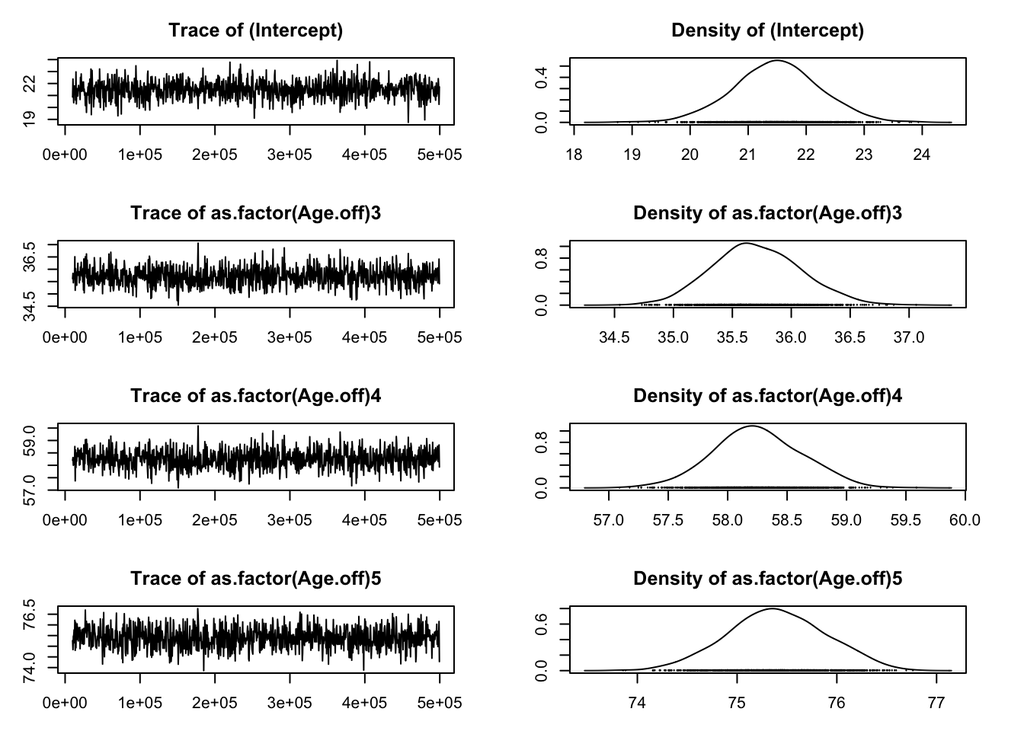

```r
par(mar=c(3,3,3,3))
plot(model.Adyo_mal$Sol)
```

Plots of random effects

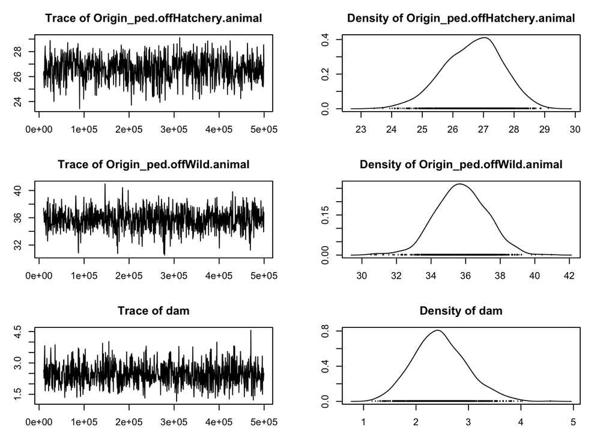

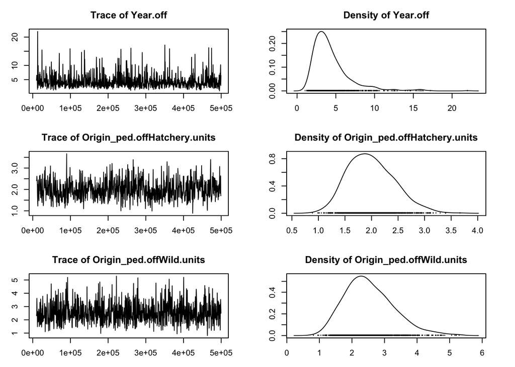

```r
par(mar=c(3,3,3,3))
plot(model.Adyo_mal$VCV)
```

```r
summary(model.Adyo_mal)
```

```
 Iterations = 10001:499501
 Thinning interval  = 500
 Sample size  = 980

 DIC: 57317.3

 G-structure:  ~idh(Origin_ped.off):animal

                              post.mean l-95% CI u-95% CI eff.samp
Origin_ped.offHatchery.animal     26.65    24.88    28.48    692.0
Origin_ped.offWild.animal         35.74    33.11    38.72    762.3

               ~dam

    post.mean l-95% CI u-95% CI eff.samp
dam     2.458    1.551    3.529      980

               ~Year.off

         post.mean l-95% CI u-95% CI eff.samp
Year.off     4.388    1.353    9.525      980

 R-structure:  ~idh(Origin_ped.off):units

                             post.mean l-95% CI u-95% CI eff.samp
Origin_ped.offHatchery.units     1.993    1.208    2.870    542.1
Origin_ped.offWild.units         2.536    1.194    4.007    980.0

 Location effects: Fork.off ~ as.factor(Age.off)

                    post.mean l-95% CI u-95% CI eff.samp  pMCMC
(Intercept)             21.49    19.92    22.83      980 <0.001 **
as.factor(Age.off)3     35.71    35.02    36.44      980 <0.001 **
as.factor(Age.off)4     58.25    57.52    58.97      980 <0.001 **
as.factor(Age.off)5     75.40    74.50    76.36      980 <0.001 **
---
Signif. codes:  0 '***' 0.001 '**' 0.01 '*' 0.05 '.' 0.1 ' ' 1
```

Plot of h2-wild

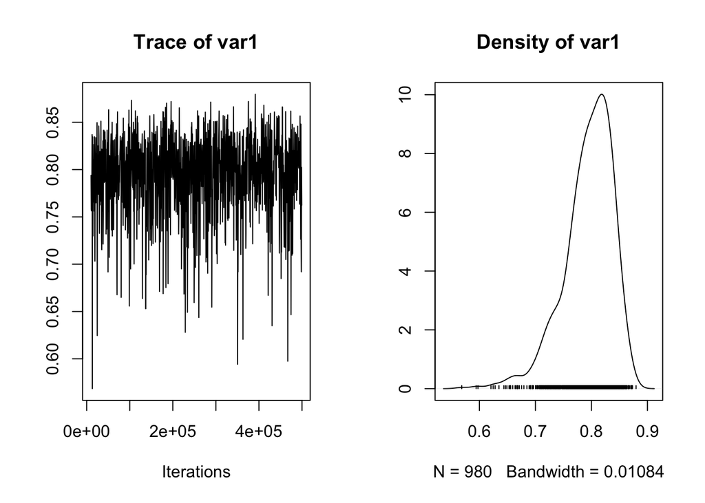

```r
posterior.heritability.fkl_mal_wild <- model.Adyo_mal$VCV[, "Origin_ped.offWild.animal"] /
  (model.Adyo_mal$VCV[, "Origin_ped.offWild.animal"] + model.Adyo_mal$VCV[, "Origin_ped.offWild.units"] + model.Adyo_mal$VCV[, "dam"] + model.Adyo_mal$VCV[, "Year.off"])
plot(posterior.heritability.fkl_mal_wild)
```

H2 estimate and 95% CI

```r
median(posterior.heritability.fkl_mal_wild)
```

```
[1] 0.8010331
```

```r
HPDinterval(posterior.heritability.fkl_mal_wild, 0.95)
```

```
         lower     upper
var1 0.7082513 0.8663895
attr(,"Probability")
[1] 0.95
```

Plot of h2-hatchery

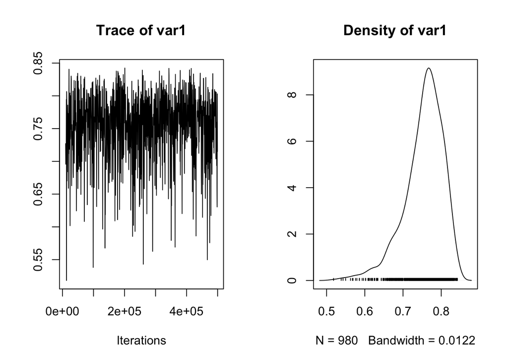

```r
posterior.heritability.fkl_mal_hat <- model.Adyo_mal$VCV[, "Origin_ped.offHatchery.animal"] /
  (model.Adyo_mal$VCV[, "Origin_ped.offHatchery.animal"] + model.Adyo_mal$VCV[, "Origin_ped.offHatchery.units"] + model.Adyo_mal$VCV[, "dam"] + model.Adyo_mal$VCV[, "Year.off"])
plot(posterior.heritability.fkl_mal_hat)
```

H2 estimate and 95% CI

```r
median(posterior.heritability.fkl_mal_hat)
```

```
[1] 0.7618876
```

```r
HPDinterval(posterior.heritability.fkl_mal_hat, 0.95)
```

```
         lower    upper
var1 0.6577046 0.840573
attr(,"Probability")
[1] 0.95
```

Autocorrelation stats

```r
autocorr.diag(model.Adyo_mal$VCV)
```

```
          Origin_ped.offHatchery.animal Origin_ped.offWild.animal         dam
Lag 0                       1.000000000               1.000000000  1.00000000
Lag 500                     0.171759401               0.048244636  0.01437597
Lag 2500                   -0.029121152               0.030156543 -0.01738132
Lag 5000                    0.015675748               0.001931146 -0.02424064
Lag 25000                   0.008261719              -0.034797862 -0.06924156
              Year.off Origin_ped.offHatchery.units Origin_ped.offWild.units
Lag 0      1.000000000                  1.000000000              1.000000000
Lag 500   -0.043383808                  0.236348945              0.021303699
Lag 2500  -0.024352649                 -0.055928656              0.054319659
Lag 5000   0.013672516                  0.007509129              0.073130074
Lag 25000 -0.003572187                  0.024251008             -0.005987665
```

## Females only - year as random effect, origin as random effect - fork length

```r
##### set up and run fkl model -
##### model2 - female only

dmal = subset(dfil,Sex_Final.off=="Female")
pvar = var(dmal$Fork.off,na.rm=T)

priorR2 <- list(
  G = list(G1 = list(V = diag(2)*pvar*.25, nu = .2), G2 = list(V = pvar*.25, nu = 0.2), G3 = list(V=pvar*.25,nu=.2)),
  R = list(R2 = list(V = diag(2)*pvar*.5, nu = .2))
)

# fork length model, age fixed effects and origin and year as random effects
model.Adyo_test_fem <- MCMCglmm(Fork.off ~ as.factor(Age.off) ,
                        random = ~ idh(Origin_ped.off):animal + dam + Year.off ,rcov = ~idh(Origin_ped.off):units,
                        family = "gaussian",
                        pedigree = pedf, data = dmal,
                        nitt = 50000, burnin = 1000, thin = 500,
                        prior = priorR2, verbose = TRUE)
save(model.Adyo_test_fem,file="model1_Adyo_test_fem.Rdata")
```

```r
load("model.Adyo_fem.Rdata")
```

Plots of fixed effects

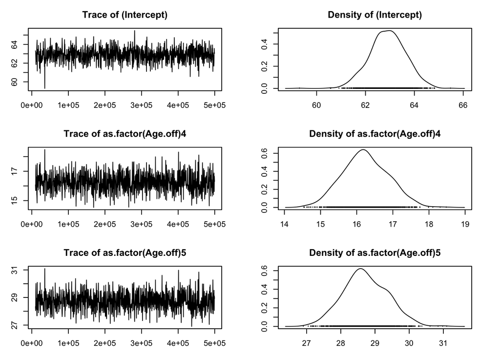

```r
par(mar=c(3,3,3,3))
plot(model.Adyo_fem$Sol)
```

Plots of random effects

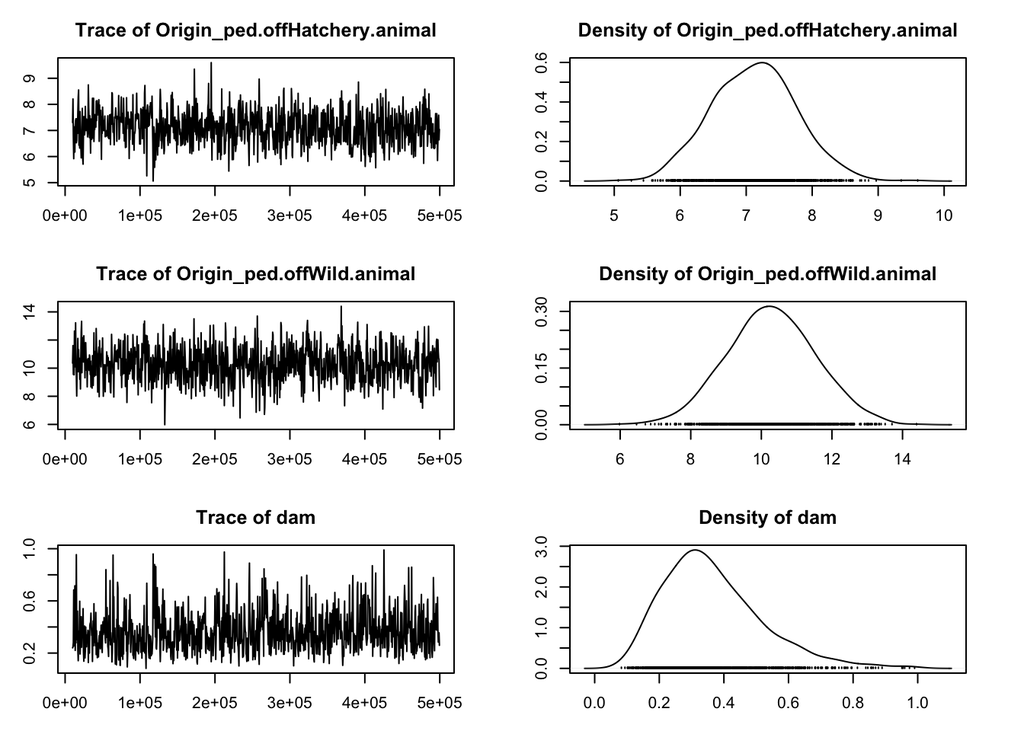

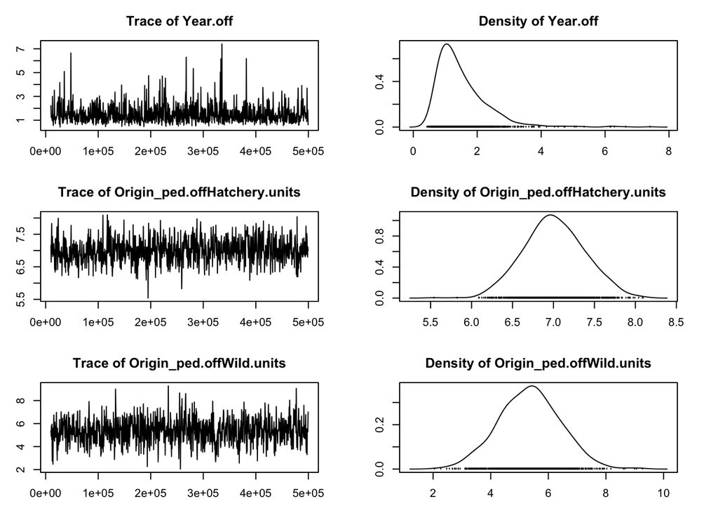

```r
par(mar=c(3,3,3,3))
plot(model.Adyo_fem$VCV)
```

```r
summary(model.Adyo_fem)
```

```
 Iterations = 10001:499501
 Thinning interval  = 500
 Sample size  = 980

 DIC: 63959.59

 G-structure:  ~idh(Origin_ped.off):animal

                              post.mean l-95% CI u-95% CI eff.samp
Origin_ped.offHatchery.animal     7.121    5.874    8.292    727.9
Origin_ped.offWild.animal        10.281    7.906   12.625    656.8

               ~dam

    post.mean l-95% CI u-95% CI eff.samp
dam    0.3663   0.1013    0.659    680.2

               ~Year.off

         post.mean l-95% CI u-95% CI eff.samp
Year.off     1.518   0.4632    2.884      980

 R-structure:  ~idh(Origin_ped.off):units

                             post.mean l-95% CI u-95% CI eff.samp
Origin_ped.offHatchery.units      7.01    6.328    7.747    743.2
Origin_ped.offWild.units          5.35    3.105    7.216    706.2

 Location effects: Fork.off ~ as.factor(Age.off)

                    post.mean l-95% CI u-95% CI eff.samp  pMCMC
(Intercept)             62.90    61.44    64.32      980 <0.001 **
as.factor(Age.off)4     16.24    15.11    17.54     1369 <0.001 **
as.factor(Age.off)5     28.72    27.56    30.06     1073 <0.001 **
---
Signif. codes:  0 '***' 0.001 '**' 0.01 '*' 0.05 '.' 0.1 ' ' 1
```

Plot of h2-wild

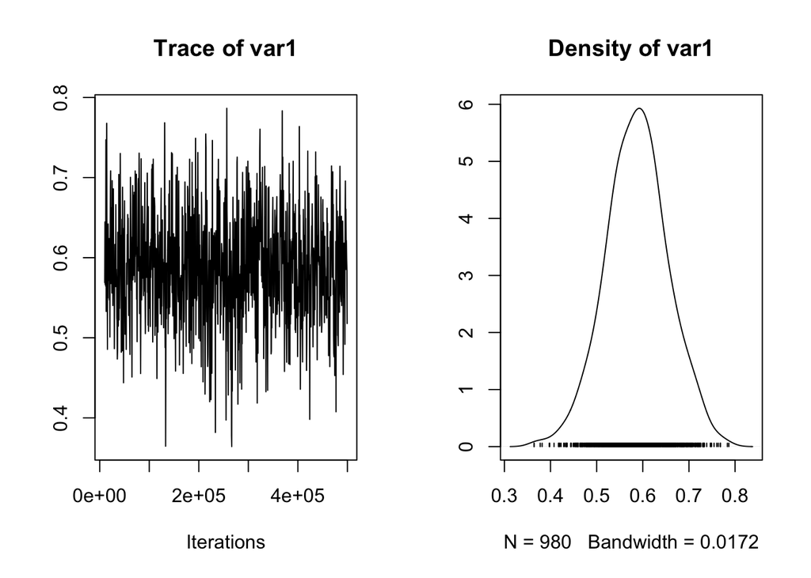

```r
posterior.heritability.fkl_fem_wild <- model.Adyo_fem$VCV[, "Origin_ped.offWild.animal"] /
  (model.Adyo_fem$VCV[, "Origin_ped.offWild.animal"] + model.Adyo_fem$VCV[, "Origin_ped.offWild.units"] + model.Adyo_fem$VCV[, "dam"] + model.Adyo_fem$VCV[, "Year.off"])
plot(posterior.heritability.fkl_fem_wild)
```

H2 estimate and 95% CI

```r
median(posterior.heritability.fkl_fem_wild)
```

```
[1] 0.5883963
```

```r
HPDinterval(posterior.heritability.fkl_fem_wild, 0.95)
```

```
         lower     upper
var1 0.4660612 0.7329958
attr(,"Probability")
[1] 0.95
```

Plot of h2-hatchery

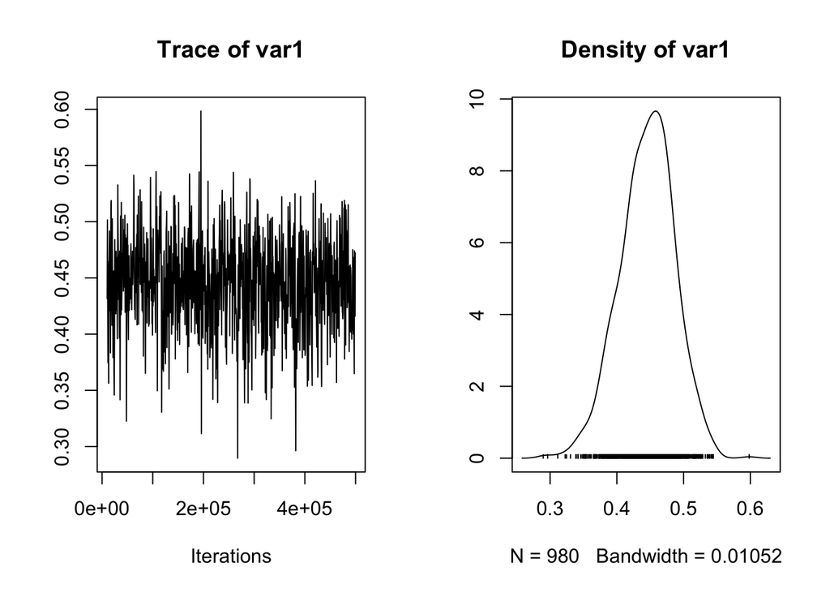

```r
posterior.heritability.fkl_fem_hat <- model.Adyo_fem$VCV[, "Origin_ped.offHatchery.animal"] /
  (model.Adyo_fem$VCV[, "Origin_ped.offHatchery.animal"] + model.Adyo_fem$VCV[, "Origin_ped.offHatchery.units"] + model.Adyo_fem$VCV[, "dam"] + model.Adyo_fem$VCV[, "Year.off"])
plot(posterior.heritability.fkl_fem_hat)
```

H2 estimate and 95% CI

```r
median(posterior.heritability.fkl_fem_hat)
```

```
[1] 0.4477377
```

```r
HPDinterval(posterior.heritability.fkl_fem_hat, 0.95)
```

```
         lower     upper
var1 0.3659017 0.5232492
attr(,"Probability")
[1] 0.95
```

Autocorrelation stats

```r
autocorr.diag(model.Adyo_fem$VCV)
```

```
          Origin_ped.offHatchery.animal Origin_ped.offWild.animal         dam
Lag 0                        1.00000000                1.00000000  1.00000000
Lag 500                      0.14711353                0.14398174  0.18011509
Lag 2500                     0.03467351                0.05251141 -0.01928528
Lag 5000                    -0.01663314                0.04258947  0.01761191
Lag 25000                    0.01748302                0.04530472 -0.02928007
               Year.off Origin_ped.offHatchery.units Origin_ped.offWild.units
Lag 0      1.0000000000                   1.00000000               1.00000000
Lag 500   -0.0309553303                   0.13689473               0.12096584
Lag 2500   0.0230119783                   0.03861527               0.05935380
Lag 5000  -0.0009142792                  -0.06057846               0.01133977
Lag 25000 -0.0256524007                   0.01897442               0.05274019
```

## Males only - year as random effect, origin as random effect - run timing

```r
##### set up and run run timing model -
##### model2 - male only

dmal = subset(dfil,Sex_Final.off=="Male")
pvar = var(dmal$Dayofyear.off,na.rm=T)

priorR2 <- list(
  G = list(G1 = list(V = diag(2)*pvar*.25, nu = .2), G2 = list(V = pvar*.25, nu = 0.2), G3 = list(V=pvar*.25,nu=.2)),
  R = list(R2 = list(V = diag(2)*pvar*.5, nu = .2))
)

#  age fixed effects and origin and year as random effects
model.Adyo_RT_mal <- MCMCglmm(Dayofyear.off ~ as.factor(Age.off) ,
                           random = ~ idh(Origin_ped.off):animal + dam + Year.off ,rcov = ~idh(Origin_ped.off):units,
                           family = "gaussian",
                           pedigree = pedf, data = dmal,
                           nitt = 500000, burnin = 10000, thin = 500,
                           prior = priorR2, verbose = TRUE)
save(model.Adyo_RT_mal,file="model.Adyo_RT_mal.Rdata")
```

```r
#### load long run from sedna
load("model.Adyo_RT_mal.Rdata")
```

Plots of fixed effects

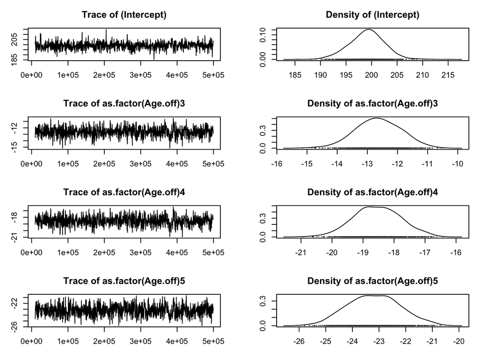

```r
par(mar=c(3,3,3,3))
plot(model.Adyo_RT_mal$Sol)
```

Plots of random effects

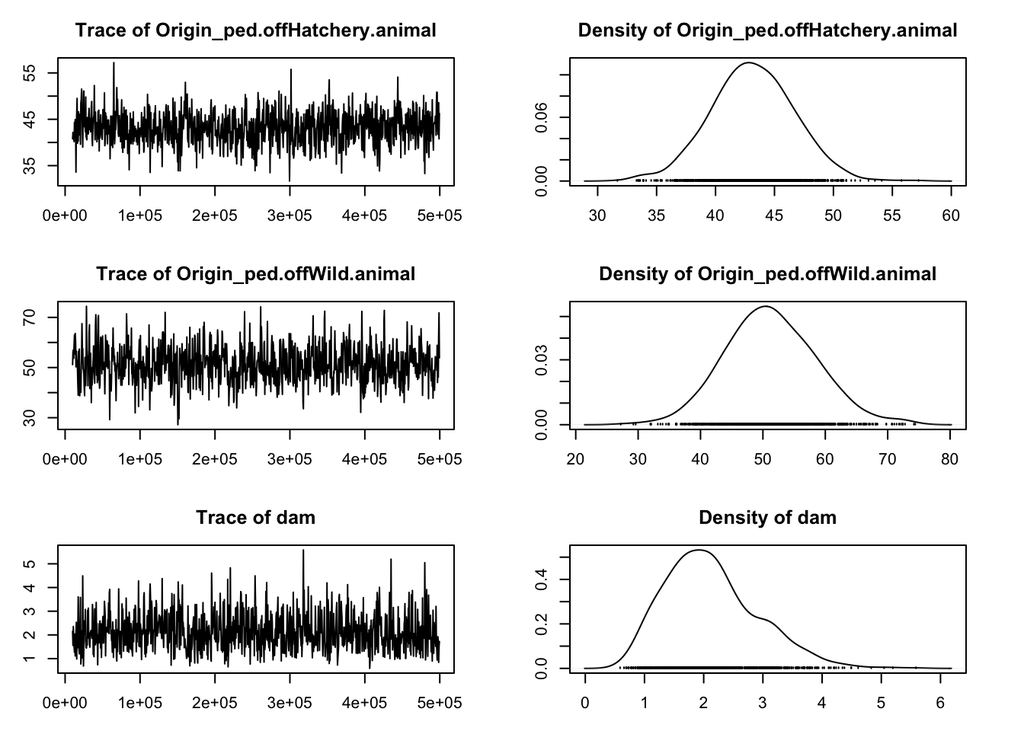

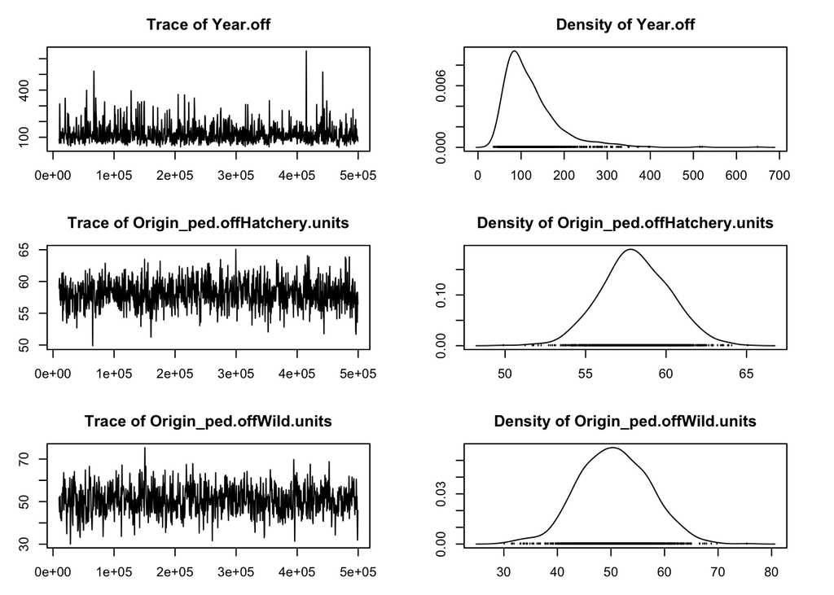

```r
par(mar=c(3,3,3,3))
plot(model.Adyo_RT_mal$VCV)
```

```r
summary(model.Adyo_RT_mal)
```

```
 Iterations = 10001:499501
 Thinning interval  = 500
 Sample size  = 980

 DIC: 93875.61

 G-structure:  ~idh(Origin_ped.off):animal

                              post.mean l-95% CI u-95% CI eff.samp
Origin_ped.offHatchery.animal     43.14    36.36    49.98    894.2
Origin_ped.offWild.animal         51.25    37.57    66.47    581.7

               ~dam

    post.mean l-95% CI u-95% CI eff.samp
dam     2.127   0.8763    3.756    777.8

               ~Year.off

         post.mean l-95% CI u-95% CI eff.samp
Year.off     122.3    42.13    252.7     1113

 R-structure:  ~idh(Origin_ped.off):units

                             post.mean l-95% CI u-95% CI eff.samp
Origin_ped.offHatchery.units     58.09    54.11    62.31      980
Origin_ped.offWild.units         50.60    38.82    63.64      663

 Location effects: Dayofyear.off ~ as.factor(Age.off)

                    post.mean l-95% CI u-95% CI eff.samp  pMCMC
(Intercept)            199.08   192.37   206.00    980.0 <0.001 **
as.factor(Age.off)3    -12.64   -14.11   -11.18    980.0 <0.001 **
as.factor(Age.off)4    -18.55   -19.93   -17.01    980.0 <0.001 **
as.factor(Age.off)5    -23.19   -24.97   -21.28    609.8 <0.001 **
---
Signif. codes:  0 '***' 0.001 '**' 0.01 '*' 0.05 '.' 0.1 ' ' 1
```

Plot of h2-wild

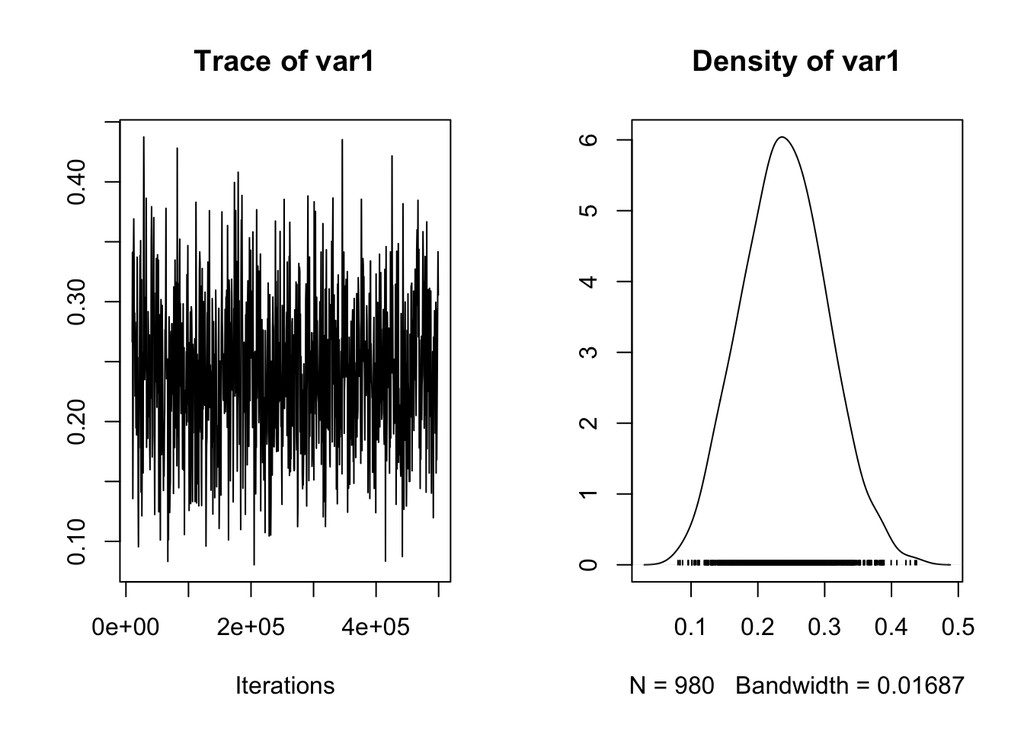

```r
posterior.heritability.RT_mal_wild <- model.Adyo_RT_mal$VCV[, "Origin_ped.offWild.animal"] /
  (model.Adyo_RT_mal$VCV[, "Origin_ped.offWild.animal"] + model.Adyo_RT_mal$VCV[, "Origin_ped.offWild.units"] + model.Adyo_RT_mal$VCV[, "dam"] + model.Adyo_RT_mal$VCV[, "Year.off"])
plot(posterior.heritability.RT_mal_wild)
```

H2 estimate and 95% CI

```r
median(posterior.heritability.RT_mal_wild)
```

```
[1] 0.238766
```

```r
HPDinterval(posterior.heritability.RT_mal_wild, 0.95)
```

```
         lower     upper
var1 0.1197528 0.3635192
attr(,"Probability")
[1] 0.95
```

Plot of h2-hatchery

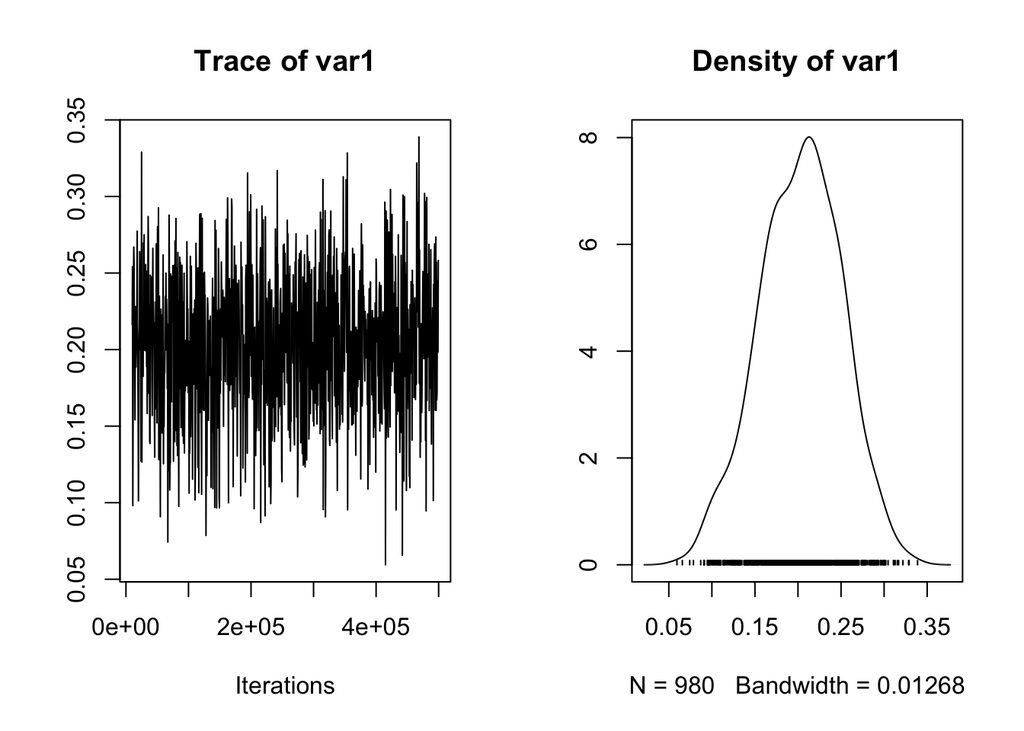

```r
posterior.heritability.RT_mal_hat <- model.Adyo_RT_mal$VCV[, "Origin_ped.offHatchery.animal"] /
  (model.Adyo_RT_mal$VCV[, "Origin_ped.offHatchery.animal"] + model.Adyo_RT_mal$VCV[, "Origin_ped.offHatchery.units"] + model.Adyo_RT_mal$VCV[, "dam"] + model.Adyo_RT_mal$VCV[, "Year.off"])
plot(posterior.heritability.RT_mal_hat)
```

H2 estimate and 95% CI

```r
median(posterior.heritability.RT_mal_hat)
```

```
[1] 0.2058327
```

```r
HPDinterval(posterior.heritability.RT_mal_hat, 0.95)
```

```
         lower     upper
var1 0.1054827 0.2926541
attr(,"Probability")
[1] 0.95
```

Autocorrelation stats

```r
autocorr.diag(model.Adyo_RT_mal$VCV)
```

```
          Origin_ped.offHatchery.animal Origin_ped.offWild.animal          dam
Lag 0                       1.000000000               1.000000000  1.000000000
Lag 500                     0.045282154               0.254539713  0.114556448
Lag 2500                    0.008535355               0.003349696 -0.012017257
Lag 5000                    0.007460004              -0.028109603  0.007273933
Lag 25000                  -0.049021144              -0.023730860 -0.052313765
              Year.off Origin_ped.offHatchery.units Origin_ped.offWild.units
Lag 0      1.000000000                   1.00000000               1.00000000
Lag 500    0.023851086                   0.04141896               0.19247046
Lag 2500   0.019721367                   0.03846826               0.01153126
Lag 5000  -0.007045686                   0.01727601               0.02030117
Lag 25000 -0.003772755                  -0.01027100              -0.03770455
```

## Females only - year as random effect, origin as random effect - run timing

```r
dmal = subset(dfil,Sex_Final.off=="Female")
pvar = var(dmal$Dayofyear.off,na.rm=T)

priorR2 <- list(
  G = list(G1 = list(V = diag(2)*pvar*.25, nu = .2), G2 = list(V = pvar*.25, nu = 0.2), G3 = list(V=pvar*.25,nu=.2)),
  R = list(R2 = list(V = diag(2)*pvar*.5, nu = .2))
)

# fork length model, age fixed effects and origin and year as random effects
model.Adyo_RT_fem <- MCMCglmm(Dayofyear.off ~ as.factor(Age.off) ,
                           random = ~ idh(Origin_ped.off):animal + dam + Year.off ,rcov = ~idh(Origin_ped.off):units,
                           family = "gaussian",
                           pedigree = pedf, data = dmal,
                           nitt = 500000, burnin = 10000, thin = 500,
                           prior = priorR2, verbose = TRUE)
save(model.Adyo_RT_fem,file="model.Adyo_RT_fem.Rdata")
```

```r
load("model.Adyo_RT_fem.Rdata")
```

Plots of fixed effects

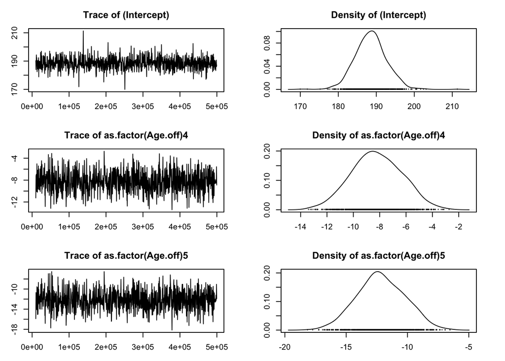

```r
par(mar=c(3,3,3,3))
plot(model.Adyo_RT_fem$Sol)
```

Plots of random effects

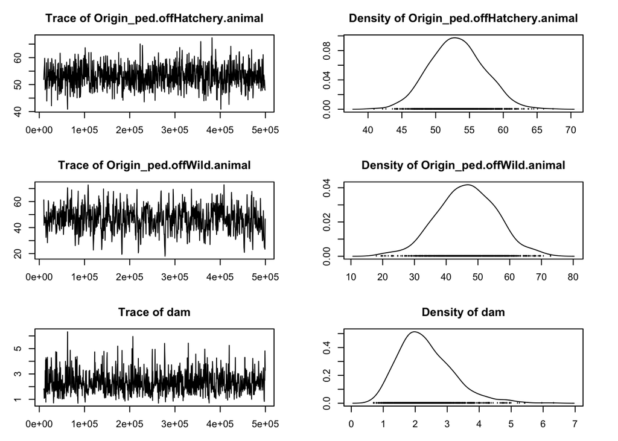

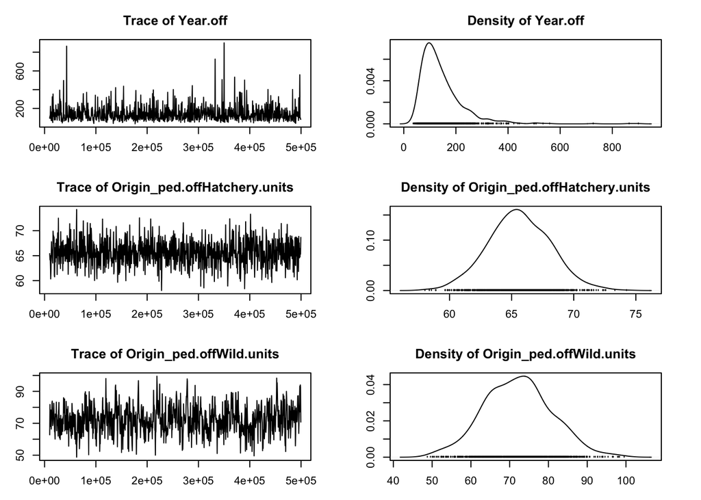

```r
par(mar=c(3,3,3,3))
plot(model.Adyo_RT_fem$VCV)
```

```r
summary(model.Adyo_RT_fem)
```

```
 Iterations = 10001:499501
 Thinning interval  = 500
 Sample size  = 980

 DIC: 91561.88

 G-structure:  ~idh(Origin_ped.off):animal

                              post.mean l-95% CI u-95% CI eff.samp
Origin_ped.offHatchery.animal     53.13     45.9    61.24    980.0
Origin_ped.offWild.animal         46.47     29.0    65.93    351.8

               ~dam

    post.mean l-95% CI u-95% CI eff.samp
dam     2.326   0.8654    4.012    821.6

               ~Year.off

         post.mean l-95% CI u-95% CI eff.samp
Year.off     143.5    39.81    299.8     1094

 R-structure:  ~idh(Origin_ped.off):units

                             post.mean l-95% CI u-95% CI eff.samp
Origin_ped.offHatchery.units     65.61    60.65    70.26    980.0
Origin_ped.offWild.units         72.13    55.65    89.78    368.3

 Location effects: Dayofyear.off ~ as.factor(Age.off)

                    post.mean l-95% CI u-95% CI eff.samp  pMCMC
(Intercept)           188.547  181.309  196.912     1097 <0.001 **
as.factor(Age.off)4    -8.231  -12.107   -4.772      980 <0.001 **
as.factor(Age.off)5   -12.153  -16.146   -8.646      980 <0.001 **
---
Signif. codes:  0 '***' 0.001 '**' 0.01 '*' 0.05 '.' 0.1 ' ' 1
```

Plot of h2-wild

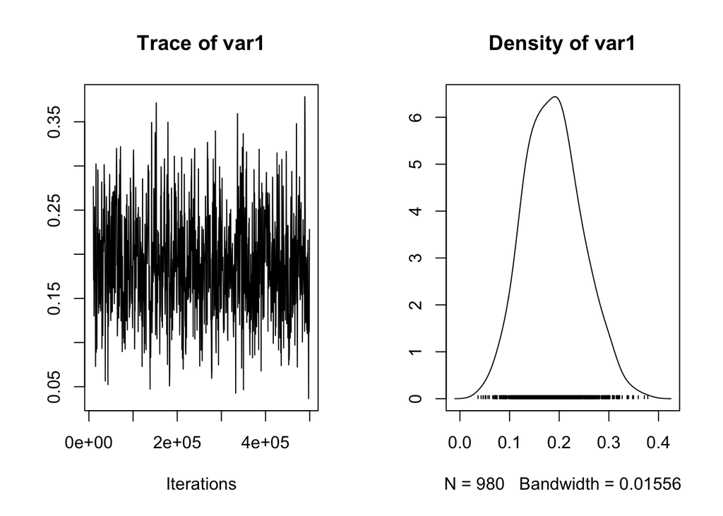

```r
posterior.heritability.RT_fem_wild <- model.Adyo_RT_fem$VCV[, "Origin_ped.offWild.animal"] /
  (model.Adyo_RT_fem$VCV[, "Origin_ped.offWild.animal"] + model.Adyo_RT_fem$VCV[, "Origin_ped.offWild.units"] + model.Adyo_RT_fem$VCV[, "dam"] + model.Adyo_RT_fem$VCV[, "Year.off"])
plot(posterior.heritability.RT_fem_wild)
```

H2 estimate and 95% CI

```r
median(posterior.heritability.RT_fem_wild)
```

```
[1] 0.1868167
```

```r
HPDinterval(posterior.heritability.RT_fem_wild, 0.95)
```

```
          lower     upper
var1 0.08592361 0.3097491
attr(,"Probability")
[1] 0.95
```

Plot of h2-hatchery

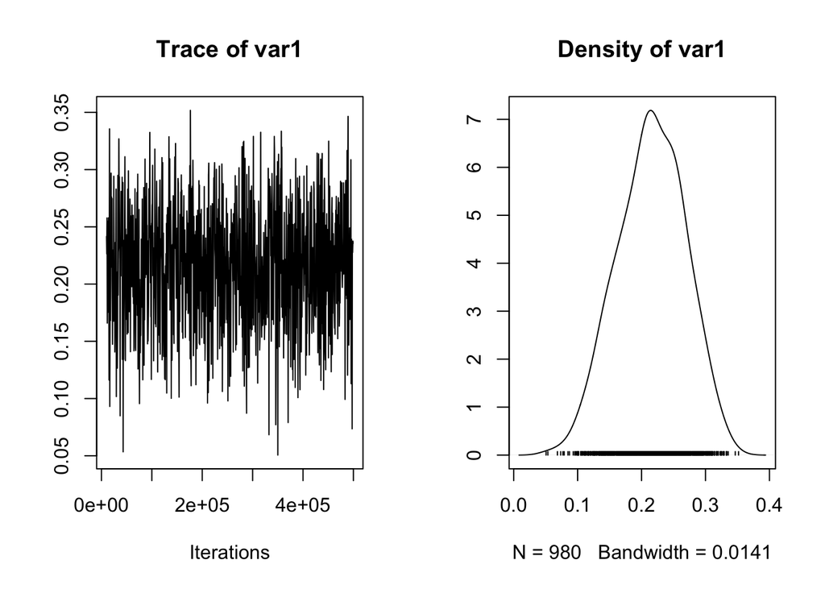

```r
posterior.heritability.RT_fem_hat <- model.Adyo_RT_fem$VCV[, "Origin_ped.offHatchery.animal"] /
  (model.Adyo_RT_fem$VCV[, "Origin_ped.offHatchery.animal"] + model.Adyo_RT_fem$VCV[, "Origin_ped.offHatchery.units"] + model.Adyo_RT_fem$VCV[, "dam"] + model.Adyo_RT_fem$VCV[, "Year.off"])
plot(posterior.heritability.RT_fem_hat)
```

H2 estimate and 95% CI

```r
median(posterior.heritability.RT_fem_hat)
```

```
[1] 0.215772
```

```r
HPDinterval(posterior.heritability.RT_fem_hat, 0.95)
```

```
         lower     upper
var1 0.1156862 0.3144192
attr(,"Probability")
[1] 0.95
```

Autocorrelation stats

```r
autocorr.diag(model.Adyo_RT_fem$VCV)
```

```
          Origin_ped.offHatchery.animal Origin_ped.offWild.animal          dam
Lag 0                        1.00000000                1.00000000  1.000000000
Lag 500                      0.01445514                0.47125240  0.087394324
Lag 2500                    -0.03624510               -0.01219689 -0.002170372
Lag 5000                    -0.03693367                0.03099958 -0.019672557
Lag 25000                   -0.01946438               -0.03752760 -0.064449929
             Year.off Origin_ped.offHatchery.units Origin_ped.offWild.units
Lag 0      1.00000000                  1.000000000               1.00000000
Lag 500   -0.05541436                  0.017358470               0.41230501
Lag 2500  -0.05776842                 -0.002808452              -0.03793564
Lag 5000  -0.00329824                 -0.006533138               0.05486962
Lag 25000 -0.07300225                 -0.005647464              -0.02722796
```

## Males only - year as random effect, origin as random effect - weight

```r
##### set up and run weight model -
##### male only

dmal = subset(dfil,Sex_Final.off=="Male")
pvar = var(dmal$Weight.off,na.rm=T)
pvar
priorR2 <- list(
  G = list(G1 = list(V = diag(2)*pvar*.25, nu = .2), G2 = list(V = pvar*.25, nu = 0.2), G3 = list(V=pvar*.25,nu=.2)),
  R = list(R2 = list(V = diag(2)*pvar*.5, nu = .2))
)

# Weight model, age fixed effects and origin and year as random effects
model.Adyo_WT_mal <- MCMCglmm(Weight.off ~ as.factor(Age.off) ,
                           random = ~ idh(Origin_ped.off):animal + dam + Year.off ,rcov = ~idh(Origin_ped.off):units,
                           family = "gaussian",
                           pedigree = pedf, data = dmal,
                           nitt = 500000, burnin = 10000, thin = 500,
                           prior = priorR2, verbose = TRUE)
save(model.Adyo_WT_mal,file="model.Adyo_WT_mal.Rdata")
```

```r
#### load long run from sedna
load("model.Adyo_WT_mal.Rdata")
```

Plots of fixed effects

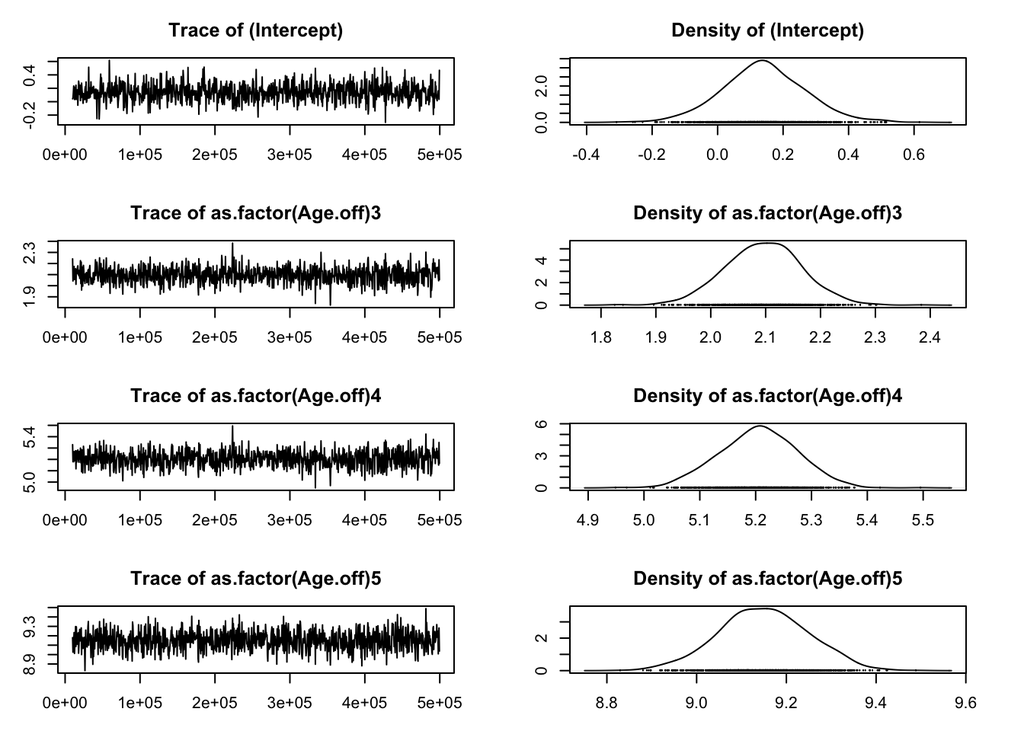

```r
par(mar=c(3,3,3,3))
plot(model.Adyo_WT_mal$Sol)
```

Plots of random effects

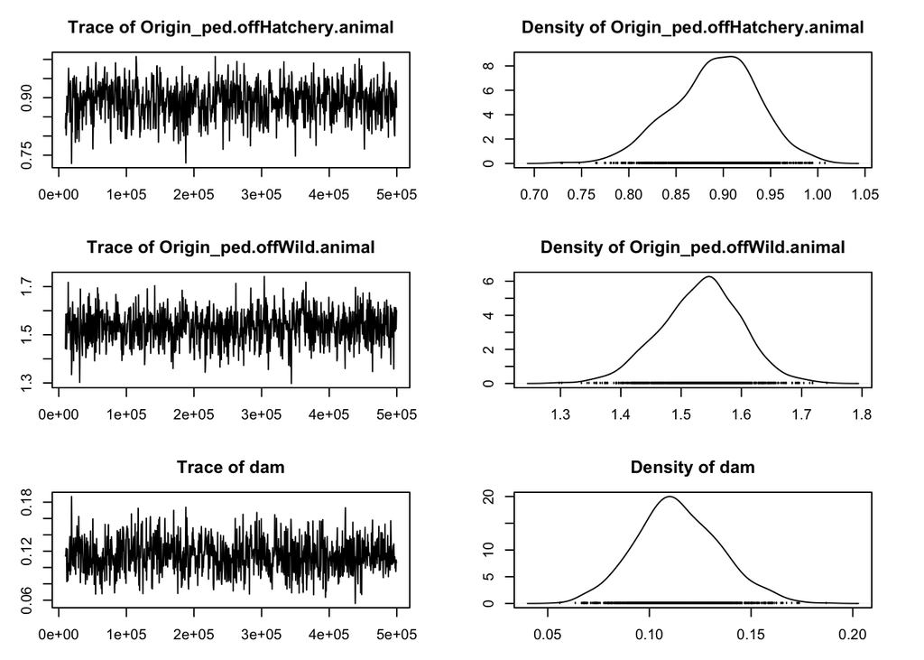

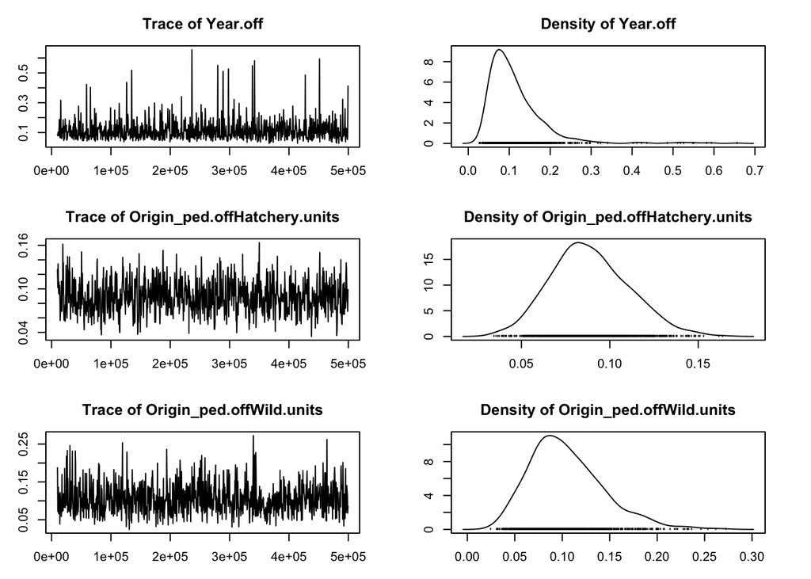

```r
par(mar=c(3,3,3,3))
plot(model.Adyo_WT_mal$VCV)
```

```r
summary(model.Adyo_WT_mal)
```

```
 Iterations = 10001:499501
 Thinning interval  = 500
 Sample size  = 980

 DIC: 16038.68

 G-structure:  ~idh(Origin_ped.off):animal

                              post.mean l-95% CI u-95% CI eff.samp
Origin_ped.offHatchery.animal    0.8912    0.793   0.9678    604.6
Origin_ped.offWild.animal        1.5325    1.400   1.6570    874.7

               ~dam

    post.mean l-95% CI u-95% CI eff.samp
dam     0.114  0.07931   0.1604    784.5

               ~Year.off

         post.mean l-95% CI u-95% CI eff.samp
Year.off    0.1139   0.0343   0.2318      980

 R-structure:  ~idh(Origin_ped.off):units

                             post.mean l-95% CI u-95% CI eff.samp
Origin_ped.offHatchery.units   0.08874  0.05096   0.1340    578.1
Origin_ped.offWild.units       0.10462  0.03722   0.1829    847.2

 Location effects: Weight.off ~ as.factor(Age.off)

                    post.mean l-95% CI u-95% CI eff.samp  pMCMC
(Intercept)            0.1408  -0.1244   0.3799    949.5  0.251
as.factor(Age.off)3    2.0957   1.9653   2.2331    980.0 <0.001 **
as.factor(Age.off)4    5.2046   5.0662   5.3313    980.0 <0.001 **
as.factor(Age.off)5    9.1496   8.9633   9.3459    980.0 <0.001 **
---
Signif. codes:  0 '***' 0.001 '**' 0.01 '*' 0.05 '.' 0.1 ' ' 1
```

Plot of h2-wild

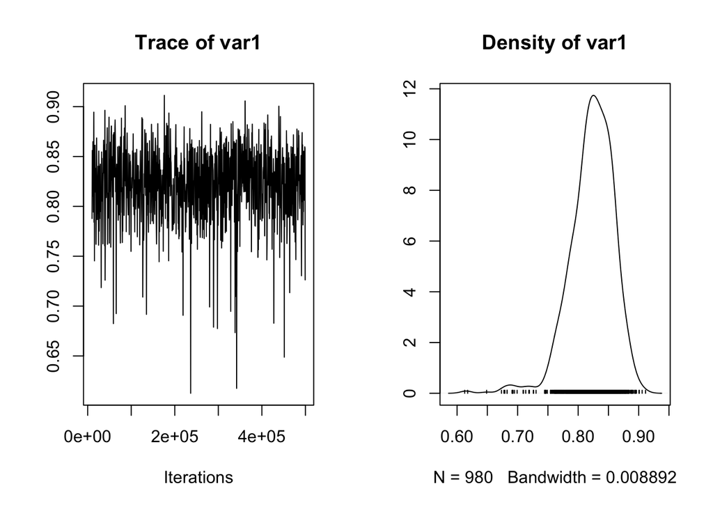

```r
posterior.heritability.WT_mal_wild <- model.Adyo_WT_mal$VCV[, "Origin_ped.offWild.animal"] /
  (model.Adyo_WT_mal$VCV[, "Origin_ped.offWild.animal"] + model.Adyo_WT_mal$VCV[, "Origin_ped.offWild.units"] + model.Adyo_WT_mal$VCV[, "dam"] + model.Adyo_WT_mal$VCV[, "Year.off"])
plot(posterior.heritability.WT_mal_wild)
```

H2 estimate and 95% CI

```r
median(posterior.heritability.WT_mal_wild)
```

```
[1] 0.8260885
```

```r
HPDinterval(posterior.heritability.WT_mal_wild, 0.95)
```

```
         lower     upper
var1 0.7546903 0.8829467
attr(,"Probability")
[1] 0.95
```

Plot of h2-hatchery

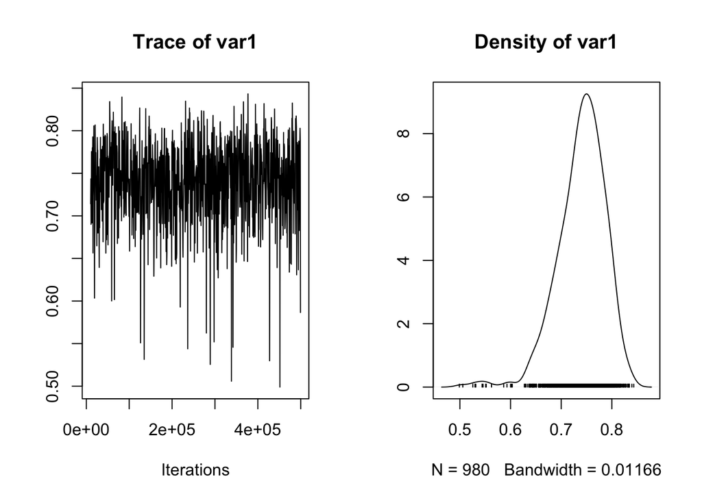

```r
posterior.heritability.WT_mal_hat <- model.Adyo_WT_mal$VCV[, "Origin_ped.offHatchery.animal"] /
  (model.Adyo_WT_mal$VCV[, "Origin_ped.offHatchery.animal"] + model.Adyo_WT_mal$VCV[, "Origin_ped.offHatchery.units"] + model.Adyo_WT_mal$VCV[, "dam"] + model.Adyo_WT_mal$VCV[, "Year.off"])
plot(posterior.heritability.WT_mal_hat)
```

H2 estimate and 95% CI

```r
median(posterior.heritability.WT_mal_hat)
```

```
[1] 0.7453349
```

```r
HPDinterval(posterior.heritability.WT_mal_hat, 0.95)
```

```
         lower     upper
var1 0.6549437 0.8266422
attr(,"Probability")
[1] 0.95
```

Autocorrelation stats

```r
autocorr.diag(model.Adyo_WT_mal$VCV)
```

```
          Origin_ped.offHatchery.animal Origin_ped.offWild.animal         dam
Lag 0                      1.0000000000               1.000000000  1.00000000
Lag 500                    0.2364221406               0.056245628  0.06091736
Lag 2500                  -0.0119988471              -0.018818702 -0.01598600
Lag 5000                  -0.0442249618              -0.010580625 -0.02278362
Lag 25000                  0.0005618648               0.009021373 -0.07829591
               Year.off Origin_ped.offHatchery.units Origin_ped.offWild.units
Lag 0      1.0000000000                  1.000000000               1.00000000
Lag 500   -0.0302415134                  0.257493105               0.07217908
Lag 2500  -0.0337310137                 -0.024268018               0.03799962
Lag 5000  -0.0467917046                 -0.044222108               0.01623569
Lag 25000  0.0009585793                  0.007780894               0.01397354
```

## Females only - year as random effect, origin as random effect - weight

```r
##### set up and run weight model -
##### female only

dmal = subset(dfil,Sex_Final.off=="Female")
pvar = var(dmal$Weight.off,na.rm=T)
pvar
summary(dmal$Weight.off)
priorR2 <- list(
  G = list(G1 = list(V = diag(2)*pvar*.25, nu = .2), G2 = list(V = pvar*.25, nu = 0.2), G3 = list(V=pvar*.25,nu=.2)),
  R = list(R2 = list(V = diag(2)*pvar*.5, nu = .2))
)

# Weight model, age fixed effects and origin and year as random effects
model.Adyo_WT_fem <- MCMCglmm(Weight.off ~ as.factor(Age.off) ,
                              random = ~ idh(Origin_ped.off):animal + dam + Year.off ,rcov = ~idh(Origin_ped.off):units,
                              family = "gaussian",
                              pedigree = pedf, data = dmal,
                              nitt = 500000, burnin = 10000, thin = 500,
                              prior = priorR2, verbose = TRUE)
save(model.Adyo_WT_fem,file="model.Adyo_WT_fem.Rdata")
```

```r
load("model.Adyo_WT_fem.Rdata")
```

Plots of fixed effects

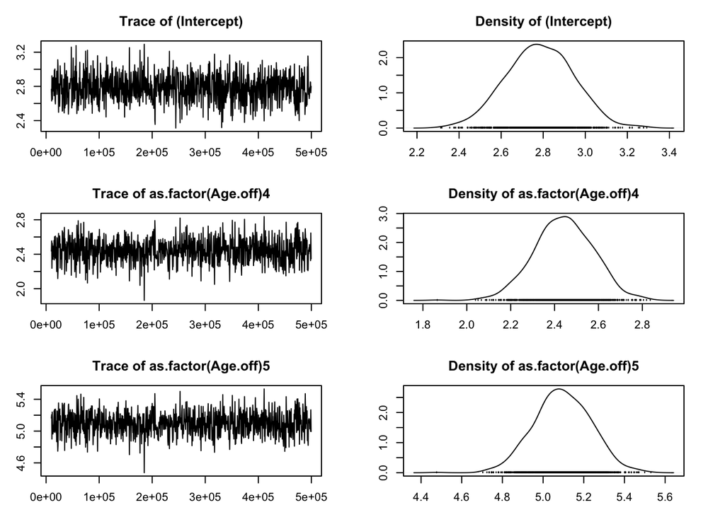

```r
par(mar=c(3,3,3,3))
plot(model.Adyo_WT_fem$Sol)
```

Plots of random effects

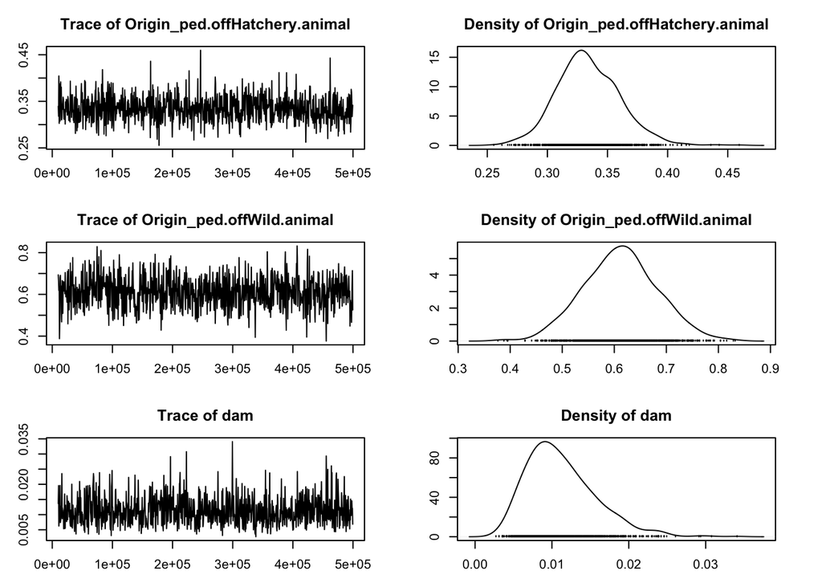

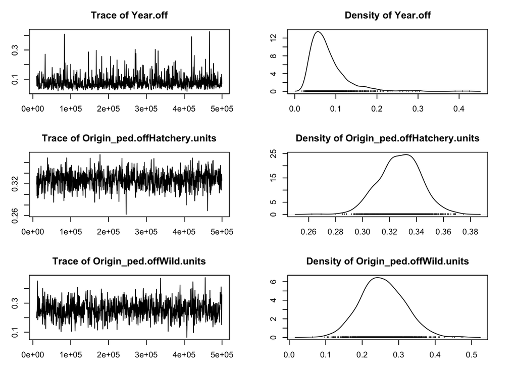

```r
par(mar=c(3,3,3,3))
plot(model.Adyo_WT_fem$VCV)
```

```r
summary(model.Adyo_WT_fem)
```

```
 Iterations = 10001:499501
 Thinning interval  = 500
 Sample size  = 980

 DIC: 26044.92

 G-structure:  ~idh(Origin_ped.off):animal

                              post.mean l-95% CI u-95% CI eff.samp
Origin_ped.offHatchery.animal    0.3340   0.2858   0.3887    980.0
Origin_ped.offWild.animal        0.6121   0.4786   0.7504    900.4

               ~dam

    post.mean l-95% CI u-95% CI eff.samp
dam    0.0112 0.003521  0.01941    782.5

               ~Year.off

         post.mean l-95% CI u-95% CI eff.samp
Year.off   0.08019  0.02498   0.1702      980

 R-structure:  ~idh(Origin_ped.off):units

                             post.mean l-95% CI u-95% CI eff.samp
Origin_ped.offHatchery.units    0.3276   0.2962   0.3564    980.0
Origin_ped.offWild.units        0.2554   0.1447   0.3721    780.3

 Location effects: Weight.off ~ as.factor(Age.off)

                    post.mean l-95% CI u-95% CI eff.samp  pMCMC
(Intercept)             2.784    2.495    3.106    980.0 <0.001 **
as.factor(Age.off)4     2.442    2.185    2.689    987.2 <0.001 **
as.factor(Age.off)5     5.095    4.821    5.355    885.3 <0.001 **
---
Signif. codes:  0 '***' 0.001 '**' 0.01 '*' 0.05 '.' 0.1 ' ' 1
```

Plot of h2-wild

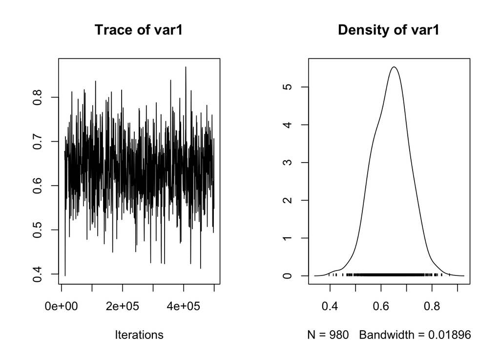

```r
posterior.heritability.WT_fem_wild <- model.Adyo_WT_fem$VCV[, "Origin_ped.offWild.animal"] /
  (model.Adyo_WT_fem$VCV[, "Origin_ped.offWild.animal"] + model.Adyo_WT_fem$VCV[, "Origin_ped.offWild.units"] + model.Adyo_WT_fem$VCV[, "dam"] + model.Adyo_WT_fem$VCV[, "Year.off"])
plot(posterior.heritability.WT_fem_wild)
```

H2 estimate and 95% CI

```r
median(posterior.heritability.WT_fem_wild)
```

```
[1] 0.6415961
```

```r
HPDinterval(posterior.heritability.WT_fem_wild, 0.95)
```

```
         lower     upper
var1 0.5022682 0.7695412
attr(,"Probability")
[1] 0.95
```

Plot of h2-hatchery

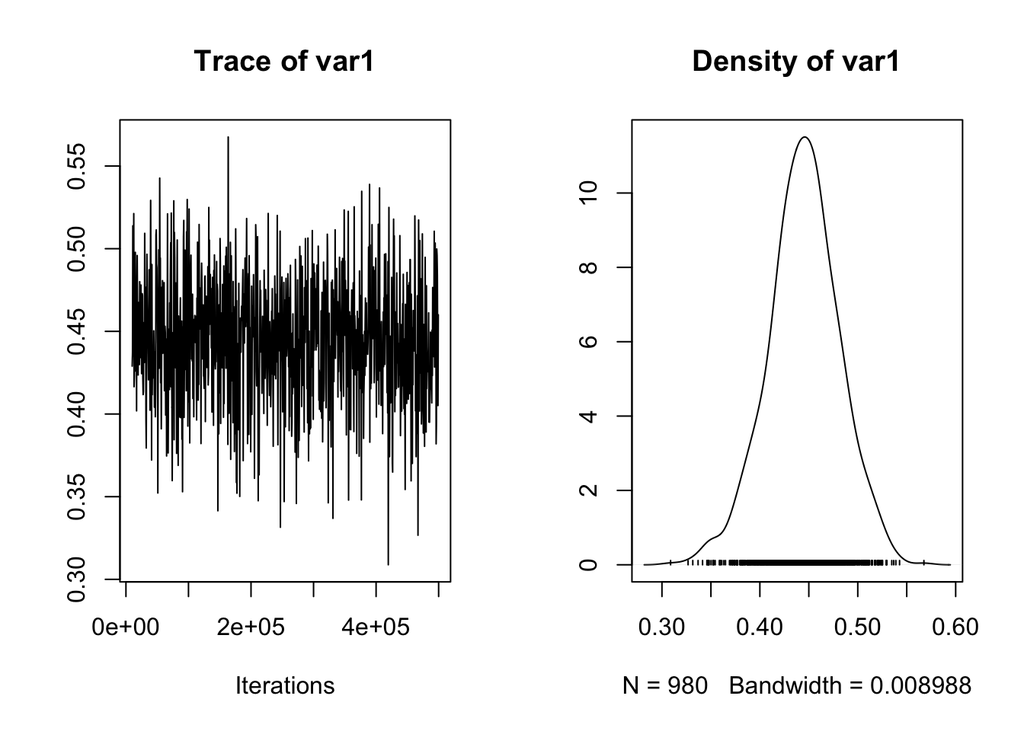

```r
posterior.heritability.WT_fem_hat <- model.Adyo_WT_fem$VCV[, "Origin_ped.offHatchery.animal"] /
  (model.Adyo_WT_fem$VCV[, "Origin_ped.offHatchery.animal"] + model.Adyo_WT_fem$VCV[, "Origin_ped.offHatchery.units"] + model.Adyo_WT_fem$VCV[, "dam"] + model.Adyo_WT_fem$VCV[, "Year.off"])
plot(posterior.heritability.WT_fem_hat)
```

H2 estimate and 95% CI

```r
median(posterior.heritability.WT_fem_hat)
```

```
[1] 0.4448458
```

```r
HPDinterval(posterior.heritability.WT_fem_hat, 0.95)
```

```
         lower    upper
var1 0.3701115 0.514644
attr(,"Probability")
[1] 0.95
```

Autocorrelation stats

```r
autocorr.diag(model.Adyo_WT_fem$VCV)
```

```
          Origin_ped.offHatchery.animal Origin_ped.offWild.animal         dam
Lag 0                       1.000000000                1.00000000  1.00000000
Lag 500                     0.003354468                0.12506676  0.11602827
Lag 2500                   -0.005016326                0.03431750  0.06519737
Lag 5000                    0.035715929                0.07919884 -0.04988071
Lag 25000                  -0.015562450                0.03612008 -0.01760841
              Year.off Origin_ped.offHatchery.units Origin_ped.offWild.units
Lag 0      1.000000000                 1.0000000000               1.00000000
Lag 500   -0.015944322                -0.0005224781               0.11776127
Lag 2500   0.008168563                -0.0242580720               0.04259864
Lag 5000  -0.020992575                 0.0039774276               0.06741946
Lag 25000  0.027967008                 0.0291551189               0.02098473
```

## Summary table

```
   trait    sex   origin        h2    lowerci   upperci
1    FKL   male     wild 0.7941040 0.70825129 0.8663895
2    FKL   male hatchery 0.7541623 0.65770465 0.8405730
3    FKL female     wild 0.5873895 0.46606117 0.7329958
4    FKL female hatchery 0.4453590 0.36590169 0.5232492
5     WT   male     wild 0.8226038 0.75469026 0.8829467
6     WT   male hatchery 0.7398079 0.65494370 0.8266422
7     WT female     wild 0.6389350 0.50226818 0.7695412
8     WT female hatchery 0.4445745 0.37011155 0.5146440
9     RT   male     wild 0.2403320 0.11975284 0.3635192
10    RT   male hatchery 0.2029315 0.10548271 0.2926541
11    RT female     wild 0.1884017 0.08592361 0.3097491
12    RT female hatchery 0.2152480 0.11568616 0.3144192
```

plot h2 results

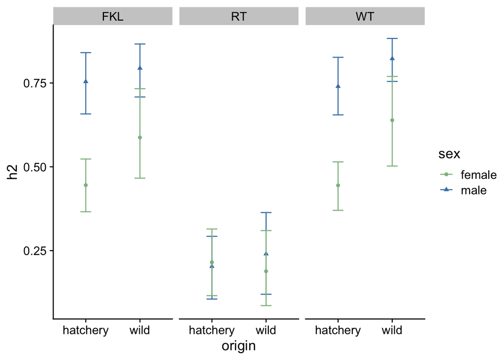

```r
plot = ggplot(data=st,aes(x=origin,y=h2,color=sex,pch=sex,ymin=lowerci,ymax=upperci)) + geom_point() + geom_errorbar(width=.2) + scale_color_manual(values=c("darkseagreen","steelblue"))+ facet_wrap(~trait) + theme_cowplot()
plot
```